# Global Disaster Visualization

David Kahler

Data from the EM-DAT database from 1901 to 2021 were analyzed. Of particular interest is drought data in southern Africa. Data available for registered users at: https://public.emdat.be/.

# Global Disasters

The EM-DAT database reports on natural, technologic, and complex disasters. Here, we consider global natural disasters (Figure 1). This is done in number of disasters and various measures of impact of these disasters.

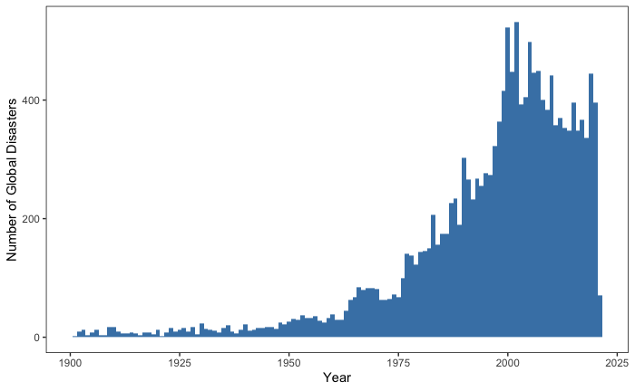

*Figure 1*: The number of disasters recorded around the globe from 1901.

# Droughts

**Table 1.** Overview of droughts and their impact, 1900-2021

| Continant | # of events | # of people killed | # of people affected | Damage (Billions USD) |
| --- | --- | --- | --- | --- |
| Africa | 334 | 856131 | 458353271 | 6.5736 |
| Americas | 166 | 130 | 111967926 | 77.2608 |
| Asia | 181 | 8413477 | 2168398277 | 57.7985 |
| Europe | 45 | 1200002 | 15488769 | 27.7813 |
| Oceania | 30 | 684 | 10742019 | 12.7909 |
| Total | 756 | 10470424 | 2764950262 | 182.2051 |

*Data source:* EM-DAT: the International Disaster Database.

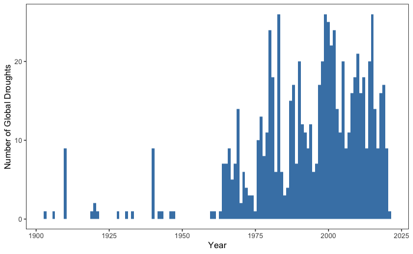

*Figure 2*: Global recorded droughts per year.

## Droughts in Southern Africa

**Table 2a.** Effect of droughts in southern Africa, 1900-2021

| Year | # of events | # of people killed | # of people affected | Damage (Billions USD) |
| --- | --- | --- | --- | --- |
| 1964 | 1 | 0 | 5000 | 0.0000 |
| 1965 | 1 | 0 | 60000 | 0.0000 |
| 1968 | 2 | 0 | 264000 | 0.0020 |
| 1970 | 1 | 0 | 87600 | 0.0020 |
| 1980 | 1 | 0 | 0 | 0.0000 |
| 1981 | 4 | 500 | 1037300 | 0.0000 |
| 1983 | 1 | 0 | 500000 | 0.0000 |
| 1984 | 1 | 0 | 0 | 0.0000 |
| 1986 | 1 | 0 | 850000 | 0.0000 |
| 1988 | 1 | 0 | 1320000 | 0.0000 |
| 1990 | 5 | 0 | 931500 | 1.0517 |
| 1995 | 2 | 0 | 463200 | 0.0000 |
| 1998 | 1 | 0 | 25000 | 0.0010 |
| 2001 | 2 | 0 | 970000 | 0.0000 |
| 2002 | 2 | 0 | 845000 | 0.0000 |
| 2004 | 1 | 0 | 15000000 | 0.0000 |
| 2007 | 2 | 0 | 885000 | 0.0000 |
| 2011 | 1 | 0 | 725515 | 0.0000 |
| 2013 | 1 | 0 | 780000 | 0.0640 |
| 2015 | 3 | 0 | 3280000 | 0.3540 |
| 2016 | 2 | 0 | 1471000 | 0.0000 |
| 2017 | 1 | 0 | 0 | 1.2000 |
| 2019 | 5 | 0 | 1742644 | 0.1350 |
| 2020 | 1 | 0 | 766000 | 0.0000 |

*Data source:* EM-DAT: the International Disaster Database.

## Limpopo Resilience Lab

This work was supported by the United States Agency for International Development, Southern Africa Regional Mission, Fixed Amount Award 72067419FA00001. This work reflects the work of the authors and does not necessarily reflect the views of USAID or the United States Government.